# Web Mining and Applied NLP (44-620)

## Employ Matplotlib and matplotlib.pyplot

### Student Name: Sushanta Shrestha

Here's the link to view my project repository on GitHub: https://github.com/sshres10/pyplot

```python
# Create and activate a Python virtual environment.
# Before starting the project, try all these imports FIRST
# Address any errors you get running this code cell
# by installing the necessary packages into your active Python environment.
# Try to resolve issues using your materials and the web.
# If that doesn't work, ask for help in the discussion forums.
# You can't complete the exercises until you import these - start early!
# We also import Counter and randint (included in the Python Standard Library).

from collections import Counter
from random import randint
import matplotlib.pyplot as plt

print('All prereqs installed.')
!pip list
```

[output not shown]

## Question 1: Frequency Bar Plot

1. Given the text below, create a bar plot (or a horizontal bar plot) that shows the frequency distribution of characters in the string. A dictionary has been created for you containing the characters and the frequencies of the characters. Make sure your bar plot has the bars labelled correctly (with the character it represents the frequency of).

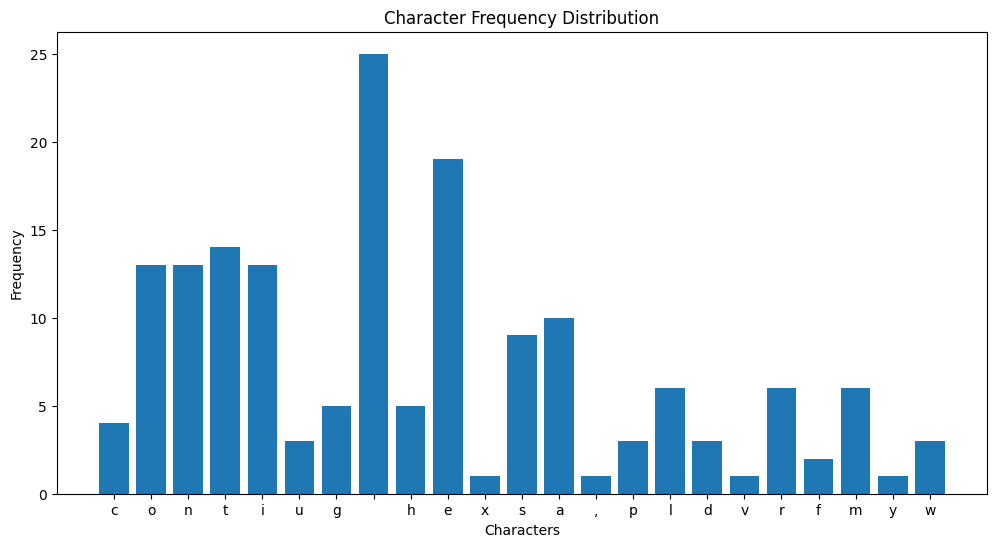

```python
from collections import Counter
import matplotlib.pyplot as plt

# Text for character frequency analysis
TEXT = "Continuing into the next season, a special gold version of the Premier League trophy was commissioned to commemorate Arsenal winning the title without a single defeat".lower()

# Calculate the frequency of each character
letter_freq = dict(Counter(TEXT))

# Plotting the bar chart
plt.figure(figsize=(12, 6))
plt.bar(letter_freq.keys(), letter_freq.values())
plt.title("Character Frequency Distribution")
plt.xlabel("Characters")
plt.ylabel("Frequency")
plt.show()
```

## Question 2: Generate and Plot Random Numbers

2. Generate a sequence of at least 5 random numbers (integers are fine), and visualize the data using both `scatter` and `plot` on different axes. You may use the index of the value as its x value in the plot.

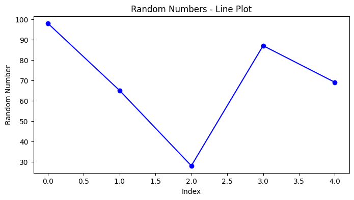

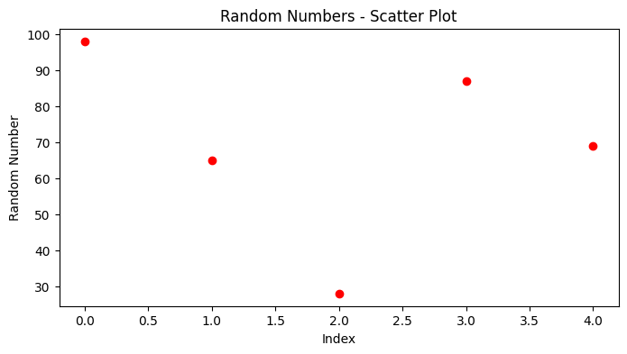

```python
import random
import matplotlib.pyplot as plt

# Generate a sequence of 5 random numbers
random_numbers = [random.randint(0, 100) for _ in range(5)]

# Line plot
plt.figure(figsize=(8, 4))
plt.plot(random_numbers, marker='o', linestyle='-', color='blue')
plt.title("Random Numbers - Line Plot")
plt.xlabel("Index")
plt.ylabel("Random Number")
plt.show()

# Scatter plot
plt.figure(figsize=(8, 4))
plt.scatter(range(len(random_numbers)), random_numbers, color='red')
plt.title("Random Numbers - Scatter Plot")
plt.xlabel("Index")
plt.ylabel("Random Number")
plt.show()
```

## Question 3: Modify Style and Color

3. Do the same question as above, but change the syle and color of both the scatter and the plot.

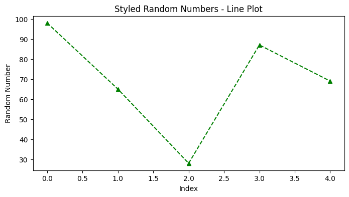

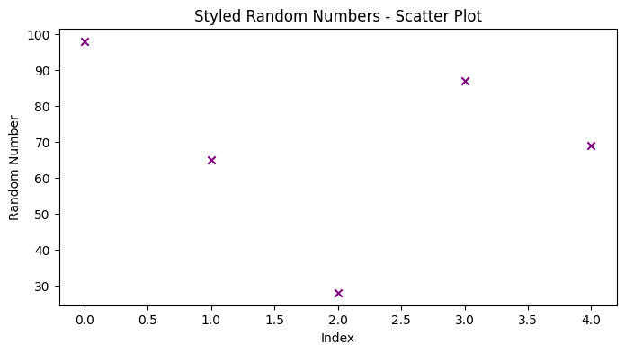

```python
# Styled line plot
plt.figure(figsize=(8, 4))
plt.plot(random_numbers, marker='^', linestyle='--', color='green')
plt.title("Styled Random Numbers - Line Plot")
plt.xlabel("Index")
plt.ylabel("Random Number")
plt.show()

# Styled scatter plot
plt.figure(figsize=(8, 4))
plt.scatter(range(len(random_numbers)), random_numbers, color='purple', marker='x')
plt.title("Styled Random Numbers - Scatter Plot")
plt.xlabel("Index")
plt.ylabel("Random Number")
plt.show()
```

### Question 4: Sorting Times Plot

4. Given the data sets below, plot or scatter both on the same set of axes. You are plotting the time it takes to execute a sorting algorithm on a list of a given size; your x axis should be the size, and the y axis is time. Assume that `insertion_sort_times[i]` is how long it took to sort a list of length `sizes[i]`. Add a legend to your plot showing which is insertion sort and which is merge sort. Use the variable names to determine which data is which.

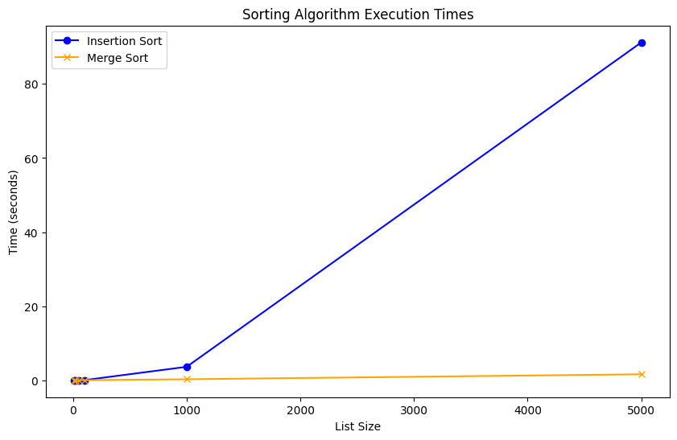

```python
sizes = [10, 20, 50, 100, 1000, 5000]
insertion_sort_times = [0.0010252999999999998, 0.0027026999999999954, 0.010147200000000002, 0.0381137, 3.6303399, 91.2180796]
merge_sort_times = [0.00161889999999687, 0.003635600000009731, 0.0090655000000055, 0.020108000000007564, 0.2687474000000094, 1.6147050999999948]

# Data for sorting times
sizes = [10, 20, 50, 100, 1000, 5000]
insertion_sort_times = [0.001, 0.0027, 0.01, 0.038, 3.63, 91.2]
merge_sort_times = [0.0016, 0.0036, 0.0096, 0.021, 0.268, 1.61]

# Plot sorting times
plt.figure(figsize=(10, 6))
plt.plot(sizes, insertion_sort_times, label="Insertion Sort", marker='o', color='blue')
plt.plot(sizes, merge_sort_times, label="Merge Sort", marker='x', color='orange')
plt.title("Sorting Algorithm Execution Times")
plt.xlabel("List Size")
plt.ylabel("Time (seconds)")
plt.legend()
plt.show()
```